# SSpMosaic integration

2025-07-30

## SSpMosaic integration

In this tutorial we showcase how to use SSpMosaic for data integration. **Before SSpMosaic integration, the `generate_module` step should be executed on each batch of data individually, followed by running the `network-propagation` step as a whole.**

## Package loading

```r
library(SSpMosaic)
```

## Set the working directory

Users can replace this directory with an appropriate path when using

```r
setwd('./')
current_dir <- getwd()
result_dir <- paste0(current_dir,'/result/')
data_dir <- paste0(current_dir,'/data/')
```

## Data loading

The input data for SSpMosaic integration should be a Seurat object containing dimensionality reduction data (e.g., PCA results) , and there should be a column in its metadata that stores the batch information corresponding to each cell.In addition, the column represented by the `cluster_col` parameter input when running the `generate_module` function separately also needs to be retained.

The example data required to run this tutorial can be downloaded from https://drive.google.com/drive/folders/1Gz1oy30BcDSrKWqWWG8GPHcSXYsYWK6P.

```r
seurat_object <- readRDS(paste0(data_dir,'PBMC_merged_data.rds'))
```

## Program label assaignment

Combine the column representing batch information in the Seurat object’s metadata with the column represented by the `cluster_col` parameter in the `generate_module` function to generate the program label corresponding to each cell.

```r
#Combine the column representing batch information(here column 'sample' ) and the cluster column used in generate_module function (here column 'Cluster')
seurat_object$program <- paste(seurat_object$sample,seurat_object$cluster,sep = '_')
```

## Load program distance matrix

Load the distance matrix generated by the function `gene_program_network_propagation_dist`

The example distance matrix required to run this tutorial can be downloaded from https://drive.google.com/drive/folders/1Gz1oy30BcDSrKWqWWG8GPHcSXYsYWK6P.

```r
distance_matrix <- read.csv(paste0(data_dir,'module_distance_matrix.csv'))
rownames(distance_matrix) <- distance_matrix[,1]
distance_matrix <- distance_matrix[,-1]
```

## Metaprogram label assaignment

Run hierarchical clustering on the program distance matrix and cut the hierarchical clustering tree to assaign metaprogram label.

```r
#Run hierarchical clustering
p <- pheatmap::pheatmap(1-distance_matrix,fontsize_row = 12,fontsize_col = 12,cellwidth = 12,cellheight = 12,clustering_method = 'mcquitty',silent = T)
#set seed for reproducibility
set.seed(123)
#Cut the hierarchical clustering tree
clu <- cutree(p$tree_row,3)
sub_clu <- clu[clu == 2]
clu <- clu[clu != 2]
clu[clu == 3] <- 2
#Run hierarchical clustering
p2 <- pheatmap::pheatmap(1-distance_matrix[names(sub_clu),names(sub_clu)],fontsize_row = 12,fontsize_col = 12,cellwidth = 12,cellheight = 12,clustering_method = 'mcquitty',silent = T)
#set seed for reproducibility
set.seed(123)
#Cut the hierarchical clustering tree
sub_clu <- cutree(p2$tree_row,2)
sub_clu <- sub_clu +2
#The correspondence between SSpMosaic metaprograms and programs
clu <- c(clu,sub_clu)
#Assign metaprogram labels to each cell based on the program labels according to the correspondence between SSpMosaic metaprograms and programs
meta_label <- ifelse(seurat_object$program %in% names(clu),
                                 clu[seurat_object$program],
                                 seurat_object$program)
#Save the metaprogram labels as a column in the Seurat object's metadata
seurat_object$meta_label <- meta_label
```

## SSpMosaic integration

The function `SSpMosaic_meta_integration.Seurat` is used to run SSpMosaic integration on a Seurat object based on the batch labels as provided and metaprogram lables as generated above.

The parameters of `SSpMosaic_meta_integration.Seurat` are as follows:

- **object**: A Seurat object containing reduction result,batch label and metaprogram label.
- **col_batch**: A string indicating the column name in the Seurat object metadata corresponding to the batch label.
- **col_SSpMosaic_cluster**: A string indicating the column name in the Seurat object metadata corresponding to the metaprogram label.
- **reduction_use**: A string indicating the name of the reduction result used for calculating distance
- **reduction_dimention**: A vector of positive integer indicating the dimensions used for calculating distance
- **batch_group_by_modality**: A list named by modality/species names, containing the batch names belonging to this modality/species.
- **n_meta_neighbors**: A positive integer indicating the number of meta neighbors.
- **neighbors_within_modality**: A positive integer,the number of cell neighbors from the same modality/species
- **neighbors_across_modality**: A positive integer,the number of cell neighbors from the different modality/species
- **graph_name**: A string indicating the name used to save the SSpMosaic integration result
- **calculate_umap**: A boolean variable that specifies whether to compute the UMAP dimensionality reduction results after integration
- **seed**: An integer indicating random seed

```r
#Specify the modality that each batch belongs to
sample_group_by_modality <- list('RNA' = c('scRNA1','scRNA2'),'Pro' = 'scPro3','ATAC' = 'scATAC4')
#Run SSpMosaic integration
res <- SSpMosaic_meta_integration.Seurat(object = seurat_object,col_batch = 'sample',col_SSpMosaic_cluster = 'meta_label',n_meta_neighbors = 1 , neighbors_within_modality = 3, neighbors_across_modality = 10,batch_group_by_modality = sample_group_by_modality,reduction_dimention = 3:30,calculate_umap = F)
#Perform clustering using the results of SSpMosaic integration
res <- FindClusters(res,graph.name = 'SSpMosaic',resolution = 0.1)
```

## Integration result

Show SSpMosaic integration result.

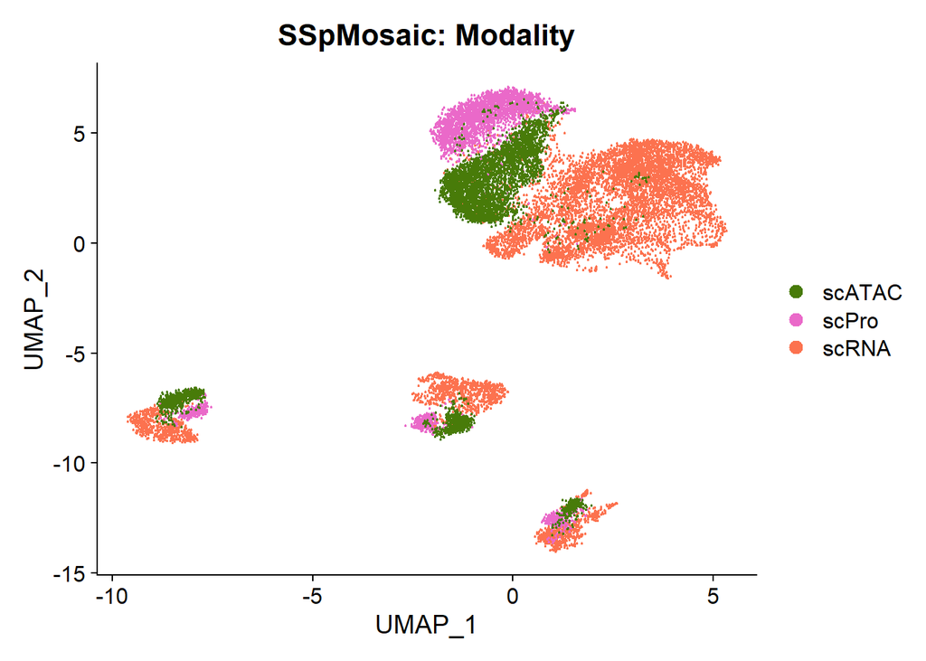

```r
#Specify the color for each modality
modalityCols <- c('#487b09', '#fc724f' ,'#ea69c9')
names(modalityCols) <- c("scATAC", "scRNA", "scPro")
#Specify the color for each celltype
celltypeCols <- c('#843C39', '#a1821c', '#d9c596', '#31A354')
names(celltypeCols) <- c('NK','Tcell','Bcell','Myeloid')
#Show integration result
DimPlot(res,reduction = 'umap',group.by = 'modality')+scale_color_manual(values = modalityCols) + labs(title = "SSpMosaic: Modality")
```

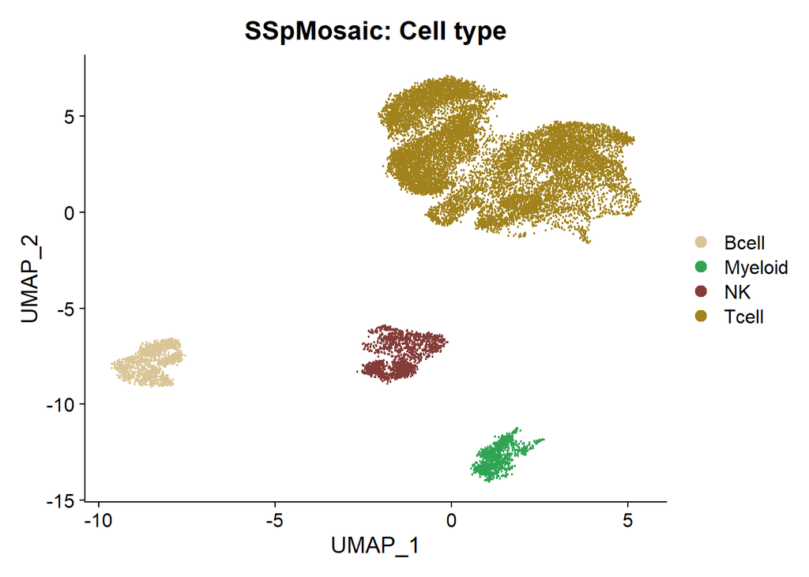

```r
DimPlot(res,reduction = 'umap',group.by = 'cluster')+scale_color_manual(values = celltypeCols) + labs(title = "SSpMosaic: Cell type")
```

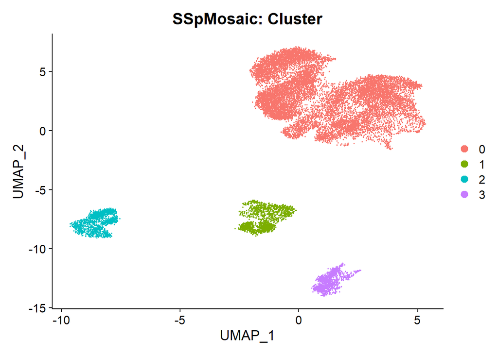

```r
DimPlot(res,reduction = 'umap',group.by = 'seurat_clusters') + labs(title = "SSpMosaic: Cluster")
```